# Elijah-Roberts'-WKH-SINDy-Project

## Abstract

The Waleffe-Kim-Hamilton model of transition and sustained turbulence is simulated and used to generate experimental data. The data then has noise added to it and is plugged into the Sparse Identification of Nonlinear Dynamics (SINDy) algorithm to generate an experimental model of the WKH system. The SINDy algorithm was found to be robust in its ability to recreate the WKH system given varying parameter sets and noise levels.

## Introduction

The goal of this project is to properly use an algorithm for the Sparse Identification of Nonlinear Dynamics (SINDy) to identify nonlinear differential equations from the Waleffe-Kim-Hamilton (WKH) model of transition and sustained turbulence. The WKH model used in this project is defined by the following equations found from [1] Kalur2020(p. 3),

$$ \begin{bmatrix} \dot{u} \\ \dot{v} \\ \dot{w} \\ \dot{m} \\ \end{bmatrix} \quad = \quad \begin{bmatrix} -\dfrac{\lambda}{Re} & 1 & 0 & 0 \\ 0 & -\dfrac{\mu}{Re} & 0 & 0 \\ 0 & 0 & -\dfrac{\nu}{Re} & 0 \\ 0 & 0 & 0 & -\dfrac{\sigma}{Re} \\ \end{bmatrix} \begin{bmatrix} u \\ v \\ w \\ m \\ \end{bmatrix} \quad + \quad \begin{bmatrix} 0 & 0 & -\gamma w & v \\ 0 & 0 & \delta w & 0 \\ \gamma w & -\delta w & 0 & 0 \\ -v & 0 & 0 & 0 \\ \end{bmatrix} \begin{bmatrix} u \\ v \\ w \\ m \\ \end{bmatrix} \tag{1} $$

Equation $(1)$ can be succinctly represented in the form,

$$\dot{x} = Ax + Q(x)x \tag{2} $$

In the state vector $x$ from $(2)$, $u$ is the amplitude of the spanwise modulation of streamwise velocity, $v$ is the amplitude of streamwise rolls, $w$ is the amplitude of the inflection streak instability and $m$ is the amplitude of the mean shear. These will be the fundamental variables monitored in the analysis of the WHK model. In the A matrix of $(2)$ the constants $\lambda$, $\mu$, $\nu$, $\sigma$, correspond to positive viscous decay rates. $Re$ is the Reynolds number. The $Q(x)$ contains the constants $\gamma$ and $\delta$ which are nonlinear interaction coefficients of equal sign.

To recreate the WKH model from simulated experimental data the SINDy function will be used. This algorithm will be of the form found in [2] Data-Driven Science and Engineering(p. 289),

$$\dot{x} = \Theta (x) \Xi \tag{3} $$

Where $\Theta (X)$ is a library of possible nonlinear functions and the columns of matrix $\Xi$ are the vectors of active coefficients. The determination of the coefficients should allow for the reconstruction of the original dynamical system based solely off of the simulated experimental data. In Figure (1) the SINDy algorithm is visualized for the Lorenz System for greater clarity.

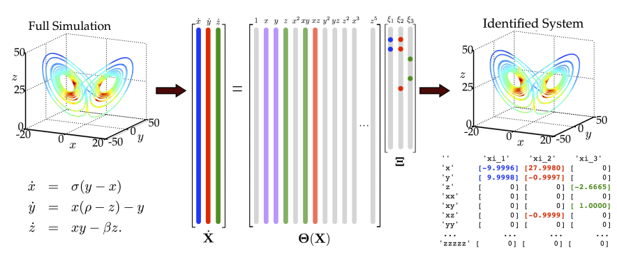

Figure (1). Schematic of SINDy algorithm. [2] Data-Driven Science and Engineering(p. 290)

## Methods

To begin the WKH model's equations as described in Eq $(1)$ are written into a function for use in simulating the system throughout the process. Using built in Python integration functions the WKH system is integrated to get values for the four major variables $u$, $v$, $w$ and $m$ over time. The derivative of these variables over time is then generated for use in the SINDy algorithm's functions. The relevant pieces of the simulated WKH model is then plugged into the SINDy algorithm. These functions are slightly modified versions of the functions found in [3] SINDY_Lorenz code provided by [2] Data-Driven Science and Engineering. From SINDy the matrix $\Xi$ as described in Eq $(3)$ is found and used to reconstruct an experimental version of the dynamical system $\dot{x}$. Specifically the viscous decay rates and nonlinear constants from Eq $(1)$ are determined algebraically from the experimental system. Both the theoretical and experimental systems are plotted for visual comparison. For quantitative analysis the mean difference of the theoretical and experimental systems are found for all four variables as well as the standard deviation of those differences. With this workflow in place, noise is then added to the simulated system seen by the SINDy algorithm to further test the robustness of the approach. The code is then iterated a preferred number of times with increasing noise value for further boundary testing.

```python
import numpy as np
import matplotlib.pyplot as plt
from matplotlib import rcParams
from mpl_toolkits.mplot3d import Axes3D
from scipy import integrate
import math
import random

#np.set_printoptions(threshold=np.inf)
```

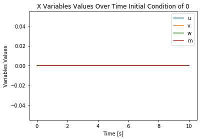

```python
## Simulate the Waleffe-Kim-Hamilton Model
t = np.linspace(0,10,1000)

lam = 10
mu = 10
nu = 15
sigma = 10
Re = 10000
gamma = 0.1
delta = 1

def WKH_deriv(uvwm, t, lam=lam, mu=mu, nu=nu, sigma=sigma, Re=Re, gamma=gamma, delta=delta):

    u = uvwm[0]
    v = uvwm[1]
    w = uvwm[2]
    m = uvwm[3]

    dudt = -(lam/Re)*u+v-gamma*(w**2)+v*m
    dvdt = -(mu/Re)*v+delta*(w**2)
    dwdt = -(nu/Re)*w+gamma*w*u-delta*w*v
    dmdt = -(sigma/Re)*m-v*u

    return np.array([dudt, dvdt, dwdt, dmdt])

x0 = np.array([0, 0, 0, 0]) #!!!!!!!!!!!!Tetsing at initial values of 0!!!!!!
X = integrate.odeint(WKH_deriv, x0, t)
utheo = X[:, 0]
vtheo = X[:, 1]
wtheo = X[:, 2]
mtheo = X[:, 3]

#plot the four variables
plt.plot(t, utheo, label="u")
plt.plot(t, vtheo, label="v")
plt.plot(t, wtheo, label="w")
plt.plot(t, mtheo, label="m")

plt.title("X Variables Values Over Time Initial Condition of 0")
plt.ylabel('Variables Values')
plt.xlabel('Time [s]')
plt.legend(loc="upper right")
plt.show()
```

## Results and Analysis

To test the accuracy of the WKH system function, the above code simulates the system with initial values of 0 for all four variables found in $x$. According to [2] Data-Driven Science and Engineering these values should correspond to the system’s equilibrium point. The expected result for an accurate WKH model is for all variables to return a value of 0. As seen in the above figure this is true for our model, confirming its accuracy.

```python
#Define mean array function
def meanarray(array):
    mean = sum(array)/len(array)
    return mean

#Define standard deviation of array function
def sdarray(array):
    sd = 0
    inside = 0

    mean = sum(array)/len(array)

    i = 0
    for i in range(len(array)):
        inside = inside + ((array[i] - mean)**2)
        i = i + 1

    sd = math.sqrt(inside/len(array))
    return sd

#Define clean up near zero values in an array function
def cleanzeros(array, threshold):
        cleanarray = np.zeros_like(array)
        j = 0
        i = 0
        for i in range(len(array)):
            if abs(array[i]) <= threshold:
                cleanarray[i] = 0
            else:
                cleanarray[i] = array[i]

            i = i + 1

        return cleanarray

#Define percent error of an array function
def percenterror(theory, experimental):
    perror = np.zeros_like(theory)
    i = 0
    for i in range(len(theory)):
        perror[i, 0] = abs((experimental[i] - theory[i, 0])/theory[i, 0])*100

    i = i + 1
    return perror

#Define difference of two arrays function
def diff(theory, experimental):
    diff = np.zeros_like(theory)
    i = 0
    for i in range(len(theory)):
        diff[i, 0] = abs(experimental[i] - theory[i, 0])

    i = i + 1
    return diff


beegn = 0
beegk = 0
for beegk in range(4): # must match the nuber of parameter sets in 'parameter_sets'

    for beegn in range(6): # equal to number of trials taken for each paramter set
        #Beeg loop start#################################################################

        print('Parameter set #', beegk+1, '- trial #', beegn+1)

        ## Simulate the Waleffe-Kim-Hamilton Model
        t = np.linspace(0,10,1000)

        parameter_sets = np.array([[10, 10, 15, 10, 1000, 0.1, 1],
                                   [10, 10, 15, 10, 10000, 0.1, 1],
                                   [1000, 1000, 1500, 10000, 10000, 0.1, 1],
                                   [10, 10, 15, 10, 10000, 1, 10]])

        lam = parameter_sets[beegk, 0]
        mu = parameter_sets[beegk, 1]
        nu = parameter_sets[beegk, 2]
        sigma = parameter_sets[beegk, 3]
        Re = parameter_sets[beegk, 4]
        gamma = parameter_sets[beegk, 5]
        delta = parameter_sets[beegk, 6]

    #     lam = random.randint(1,100)
    #     mu = random.randint(1,100)
    #     nu = random.randint(1,150)
    #     sigma = random.randint(1,100)
    #     Re = 100
    #     gamma = random.randint(1,10)
    #     delta = random.randint(1,10)

        def WKH_deriv(uvwm, t, lam=lam, mu=mu, nu=nu, sigma=sigma, Re=Re, gamma=gamma, delta=delta):

            u = uvwm[0]
            v = uvwm[1]
            w = uvwm[2]
            m = uvwm[3]

            dudt = -(lam/Re)*u+v-gamma*(w**2)+v*m
            dvdt = -(mu/Re)*v+delta*(w**2)
            dwdt = -(nu/Re)*w+gamma*w*u-delta*w*v
            dmdt = -(sigma/Re)*m-v*u

            return np.array([dudt, dvdt, dwdt, dmdt])

        x0 = np.array([1, 2, 3, 4]) # find resonable starting values
        X = integrate.odeint(WKH_deriv, x0, t)
        utheo = X[:, 0]
        vtheo = X[:, 1]
        wtheo = X[:, 2]
        mtheo = X[:, 3]

        #plot the four variables
        plt.plot(t, utheo, label="u")
        plt.plot(t, vtheo, label="v")
        plt.plot(t, wtheo, label="w")
        plt.plot(t, mtheo, label="m")

        plt.title("X Variables Values Over Time")
        plt.ylabel('Variables Values')
        plt.xlabel('Time [s]')
        plt.legend(loc="upper right")
        plt.show()



        ##generate the random noise array
        murand, sigmarand = 0, 0.2*beegn # mean and standard deviation
        noisearray = np.random.normal(murand, sigmarand, (len(X), len(X[0])))
        #print('standard deviation of noise array: ', sigmarand)
        #print('Noise array:\n', noisearray)
        #print('length', len(noisearray))
        #print('width', len(noisearray[0]))

        #print('base X', X)
        X = X + noisearray
        u = X[:, 0]
        v = X[:, 1]
        w = X[:, 2]
        m = X[:, 3]
        #print('X + rand', X)


        ## Compute Derivative
        dx = np.zeros_like(X)
        for j in range(len(t)):
            dx[j,:] = WKH_deriv(X[j,:],0)



        ## SINDy Function Definitions
        def poolData(yin,nVars,polyorder):
            n = yin.shape[0]
            yout = np.zeros((n,1))

            # poly order 0
            yout[:,0] = np.ones(n)

            # poly order 1
            for i in range(nVars):
                yout = np.append(yout,yin[:,i].reshape((yin.shape[0],1)),axis=1)

            # poly order 2
            if polyorder >= 2:
                for i in range(nVars):
                    for j in range(i,nVars):
                        yout = np.append(yout,(yin[:,i]*yin[:,j]).reshape((yin.shape[0],1)),axis=1)

            # poly order 3
            if polyorder >= 3:
                for i in range(nVars):
                    for j in range(i,nVars):
                        for k in range(j,nVars):
                            yout = np.append(yout,(yin[:,i]*yin[:,j]*yin[:,k]).reshape((yin.shape[0],1)),axis=1)

            return yout

        def sparsifyDynamics(Theta,dXdt,lamb,n):
            Xi = np.linalg.lstsq(Theta,dXdt,rcond=None)[0] # Initial guess: Least-squares

            for k in range(10):
                smallinds = np.abs(Xi) < lamb # Find small coefficients
                Xi[smallinds] = 0                          # and threshold
                for ind in range(n):                       # n is state dimension
                    biginds = smallinds[:,ind] == 0
                    # Regress dynamics onto remaining terms to find sparse Xi
                    Xi[biginds,ind] = np.linalg.lstsq(Theta[:,biginds],dXdt[:,ind],rcond=None)[0]

            return Xi



        ## Find Constants with SINDy
        n = 4 # number of variables- 4 for u v w m.

        Theta = poolData(X,n,3) # Up to third order polynomials
        lamb = 0.025 # 0.025 # sparsification knob lambda
        Xi = sparsifyDynamics(Theta,dx,lamb,n)
```

```python
        #print results
        A = np.array([[-(lam/Re), 1, 0, 0],
                      [0, -(mu/Re), 0, 0],
                      [0, 0, -(nu/Re), 0],
                      [0, 0, 0, -(sigma/Re)]])

        Q = np.array([[0, 0, -(gamma), 1],
                      [0, 0, delta, 0],
                      [gamma, -(delta), 0, 0],
                      [-1, 0, 0, 0]])

    #     print('A gives :\n', A)
    #     print('Q gives :\n', Q)
    #     print('SINDy (transpose) gives :\n', np.transpose(Xi))
    #     print('length of Xi :\n', len(Xi))
    #     print('Width of Xi :\n', len(Xi[0]))
    #     print('constants for u :\n', Xi[:, 0])
    #     print('constants for u length :\n', len(Xi[:, 0]))



        ## Construct the expirmmental dXdtE function
        # ordername will only function for 3rd order polynomials
        ordername = np.array([[np.ones_like(u), u, v, w, m,
                               u*u, u*v, u*w, u*m, v*v, v*w, v*m, w*w, w*m, m*m,
                               u*u*u, u*u*v, u*u*w, u*u*m, u*v*v, u*v*w, u*v*m, u*w*w, u*w*m, u*m*m, v*v*v, v*v*w, v*v*m, v*w*w, v*w*m, v*m*m, w*w*w, w*w*m, w*m*m, m*m*m]])

        #find experimental parameter list
        lamE = -Re*Xi[1, 0]
        muE = -Re*Xi[2, 1]
        nuE = -Re*Xi[3, 2]
        sigmaE = -Re*Xi[4, 3]
        gammaEu = -Xi[12, 0]
        gammaEw = Xi[7, 2]
        deltaEv = Xi[12, 1]
        deltaEw = -Xi[10, 2]

        #find experimental dynamical system
        dudtE = np.zeros_like(u)
        dvdtE = np.zeros_like(v)
        dwdtE = np.zeros_like(w)
        dmdtE = np.zeros_like(m)

        j = 0
        for j in range(len(Xi[0])):

            i = 0
            for i in range(len(Xi)):

                if Xi[i, j] != 0 and j == 0:
                    dudtE = dudtE + (Xi[i, j])*ordername[0, i]
                    i = i + 1
                elif Xi[i, j] != 0 and j == 1:
                    dvdtE = dvdtE + (Xi[i, j])*ordername[0, i]
                    i = i + 1
                elif Xi[i, j] != 0 and j == 2:
                    dwdtE = dwdtE + (Xi[i, j])*ordername[0, i]
                    i = i + 1
                elif Xi[i, j] != 0 and j == 3:
                    dmdtE = dmdtE + (Xi[i, j])*ordername[0, i]
                    i = i + 1
                else:
                    i = i + 1

            j = j + 1

        #clean up the experimental dynamical system
    #     threshold = 1e-6
    #     dudtE = cleanzeros(dudtE, threshold)
    #     dvdtE = cleanzeros(dvdtE, threshold)
    #     dwdtE = cleanzeros(dwdtE, threshold)
    #     dmdtE = cleanzeros(dmdtE, threshold)

        #print expirmmental dXdtE function results
        # print('dudtE :\n', dudtE)
        # print('length dudtE :\n', len(dudtE))

        # print('dvdtE :\n', dvdtE)
        # print('length dvdtE :\n', len(dvdtE))

        # print('dwdtE :\n', dwdtE)
        # print('length dwdtE :\n', len(dwdtE))

        # print('dmdtE :\n', dmdtE)
        # print('length dmdtE :\n', len(dmdtE))



        ## construct the theoretical components of dXdt to compare to
        uvwm = np.array([[utheo], [vtheo], [wtheo], [mtheo]])

        dXdt = WKH_deriv(uvwm, t, lam=lam, mu=mu, nu=nu, sigma=sigma, Re=Re, gamma=gamma, delta=delta)
        dudt = np.transpose(dXdt[0])
        dvdt = np.transpose(dXdt[1])
        dwdt = np.transpose(dXdt[2])
        dmdt = np.transpose(dXdt[3])

        #clean up the experimental dynamical system
    #     threshold = 1e-6
    #     dudt = cleanzeros(dudt, threshold)
    #     dvdt = cleanzeros(dvdt, threshold)
    #     dwdt = cleanzeros(dwdt, threshold)
    #     dmdt = cleanzeros(dmdt, threshold)


        ## Find the difference(error) of the experimental dXdtE
        errordudtraw = diff(dudt, dudtE)
        errordvdtraw = diff(dvdt, dvdtE)
        errordwdtraw = diff(dwdt, dwdtE)
        errordmdtraw = diff(dmdt, dmdtE)



        ##plot the theoretical and experimental dynamical system
        #theortical
        plt.plot(t, dudt, label="dudt")
        plt.plot(t, dvdt, label="dvdt")
        plt.plot(t, dwdt, label="dwdt")
        plt.plot(t, dmdt, label="dmdt")

        plt.title("Theortical Dynamical System")
        plt.ylabel('Dynamic Variable Values')
        plt.xlabel('Time [s]')
        plt.legend(loc="upper right")
        plt.show()

        #print standard deviation of noise array
        print('Standard deviation of noise array: ', sigmarand)

        #Experimental
        plt.plot(t, dudtE, label="dudtE")
        plt.plot(t, dvdtE, label="dvdtE")
        plt.plot(t, dwdtE, label="dwdtE")
        plt.plot(t, dmdtE, label="dmdtE")

        plt.title("Experimental Dynamical System")
        plt.ylabel('Dynamic Variable Values')
        plt.xlabel('Time [s]')
        plt.legend(loc="upper right")
        plt.show()



        ##Major info prints
    #     print('difference of experimental dudt :\n', errordudtraw)
    #     print('difference of experimental dvdt :\n', errordvdtraw)
    #     print('difference of experimental dwdt :\n', errordwdtraw)
    #     print('difference of experimental dmdt :\n', errordmdtraw)


    #     print('dudt :\n', dudt)
    #     print('dudtE :\n', dudtE)

    #     print('dvdt :\n', dvdt)
    #     print('dvdtE :\n', dvdtE)

    #     print('dwdt :\n', dwdt)
    #     print('dwdtE :\n', dwdtE)

    #     print('dmdt :\n', dmdt)
    #     print('dmdtE :\n', dmdtE)


        print('mean difference of dudt :\n', meanarray(errordudtraw))
        print('standard deviation of error of dudt :\n', sdarray(errordudtraw))

        print('mean difference of dvdt :\n', meanarray(errordvdtraw))
        print('standard deviation of error of dvdt :\n', sdarray(errordvdtraw))

        print('mean difference of dwdt :\n', meanarray(errordwdtraw))
        print('standard deviation of error of dwdt :\n', sdarray(errordwdtraw))

        print('mean difference of dmdt :\n', meanarray(errordmdtraw))
        print('standard deviation of error of dmdt :\n', sdarray(errordmdtraw))

        print('\n') #spacing
        print('Lambda: ', lam)
        print('Mu: ', mu)
        print('Nu: ', nu)
        print('sigma: ', sigma)
        print('Re: ', Re)
        print('gamma: ', gamma)
        print('delta: ', delta)
```

```
Parameter set # 1 - trial # 1
```

```
Standard deviation of noise array:  0.0
```

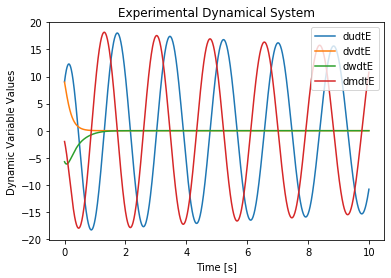

```
mean difference of dudt :
 [0.02971316]
standard deviation of error of dudt :
 0.014682983044751694
mean difference of dvdt :
 [0.03455591]
standard deviation of error of dvdt :
 0.004059953061906908
mean difference of dwdt :
 [0.00020802]
standard deviation of error of dwdt :
 0.0006412367225254482
mean difference of dmdt :
 [0.03149081]
standard deviation of error of dmdt :
 0.016661875163351905


Lambda:  10.0
Mu:  10.0
Nu:  15.0
sigma:  10.0
Re:  1000.0
gamma:  0.1
delta:  1.0


Lambda experimental:  -0.0
Mu experimental:  -0.0
Nu experimental:  -0.0
sigma experimental:  -0.0
gamma experimental from dudt:  0.10491945417384217
gamma experimental from dwdt:  0.10239600423416279
delta experimental from dvdt:  0.9943117768301207
delta experimental from dwdt:  1.0074073776005283




Parameter set # 1 - trial # 2
```

```
Standard deviation of noise array:  0.2
```

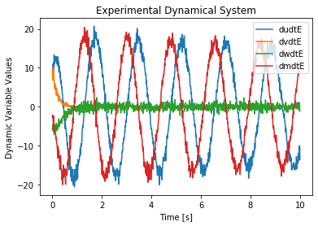

```
mean difference of dudt :
 [0.780536]
standard deviation of error of dudt :
 0.6041497523757836
mean difference of dvdt :
 [0.0980846]
standard deviation of error of dvdt :
 0.16079878359073368
mean difference of dwdt :
 [0.56846931]
standard deviation of error of dwdt :
 0.4129010323818662
mean difference of dmdt :
 [0.77177796]
standard deviation of error of dmdt :
 0.6192613337990545


Lambda:  10.0
Mu:  10.0
Nu:  15.0
sigma:  10.0
Re:  1000.0
gamma:  0.1
delta:  1.0


Lambda experimental:  -0.0
Mu experimental:  -0.0
Nu experimental:  -0.0
sigma experimental:  -0.0
gamma experimental from dudt:  0.10488965309003474
gamma experimental from dwdt:  0.09994296990716056
delta experimental from dvdt:  0.9930984167967964
delta experimental from dwdt:  1.0048905998488347




Parameter set # 1 - trial # 3
```

```
Standard deviation of noise array:  0.4
```

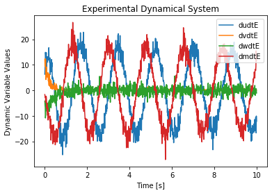

```
mean difference of dudt :
 [1.58410719]
standard deviation of error of dudt :
 1.2501515262373062
mean difference of dvdt :
 [0.24009308]
standard deviation of error of dvdt :
 0.386561789182402
mean difference of dwdt :
 [1.13202313]
standard deviation of error of dwdt :
 0.873479895305956
mean difference of dmdt :
 [1.56024074]
standard deviation of error of dmdt :
 1.3067077593140295


Lambda:  10.0
Mu:  10.0
Nu:  15.0
sigma:  10.0
Re:  1000.0
gamma:  0.1
delta:  1.0


Lambda experimental:  -0.0
Mu experimental:  -0.0
Nu experimental:  -0.0
sigma experimental:  -0.0
gamma experimental from dudt:  0.1036083629356913
gamma experimental from dwdt:  0.09984712885460736
delta experimental from dvdt:  0.9918607206074301
delta experimental from dwdt:  1.0044514815571832




Parameter set # 1 - trial # 4
```

```
Standard deviation of noise array:  0.6000000000000001
```

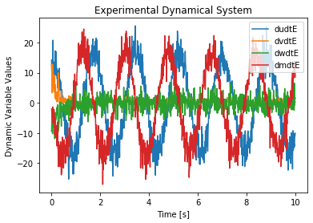

```
mean difference of dudt :
 [2.33116901]
standard deviation of error of dudt :
 1.7630378006954628
mean difference of dvdt :
 [0.47938036]
standard deviation of error of dvdt :
 0.6888276422750316
mean difference of dwdt :
 [1.70404922]
standard deviation of error of dwdt :
 1.346958915959185
mean difference of dmdt :
 [2.25776577]
standard deviation of error of dmdt :
 1.8032241387515668


Lambda:  10.0
Mu:  10.0
Nu:  15.0
sigma:  10.0
Re:  1000.0
gamma:  0.1
delta:  1.0


Lambda experimental:  -0.0
Mu experimental:  -0.0
Nu experimental:  -0.0
sigma experimental:  -0.0
gamma experimental from dudt:  0.10323540099216624
gamma experimental from dwdt:  0.09990120293486718
delta experimental from dvdt:  0.9894341535825112
delta experimental from dwdt:  1.004300659429315




Parameter set # 1 - trial # 5
```

```
Standard deviation of noise array:  0.8
```

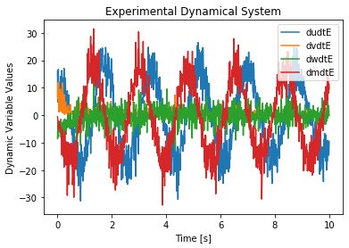

```
mean difference of dudt :
 [3.12167703]
standard deviation of error of dudt :
 2.481643913679347
mean difference of dvdt :
 [0.73061514]
standard deviation of error of dvdt :
 1.0140863117750745
mean difference of dwdt :
 [2.23542791]
standard deviation of error of dwdt :
 1.8567384166317829
mean difference of dmdt :
 [3.29120524]
standard deviation of error of dmdt :
 2.5851741735268887


Lambda:  10.0
Mu:  10.0
Nu:  15.0
sigma:  10.0
Re:  1000.0
gamma:  0.1
delta:  1.0


Lambda experimental:  -0.0
Mu experimental:  -0.0
Nu experimental:  -0.0
sigma experimental:  -0.0
gamma experimental from dudt:  0.10257980086864922
gamma experimental from dwdt:  0.09985851936490073
delta experimental from dvdt:  0.9890120790013346
delta experimental from dwdt:  1.0040952586410408




Parameter set # 1 - trial # 6
```

```
Standard deviation of noise array:  1.0
```

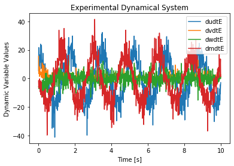

```
mean difference of dudt :
 [4.0335681]
standard deviation of error of dudt :
 3.195659252018624
mean difference of dvdt :
 [1.13308753]
standard deviation of error of dvdt :
 1.5612307472149527
mean difference of dwdt :
 [2.86101225]
standard deviation of error of dwdt :
 2.3879008308732868
mean difference of dmdt :
 [3.88032839]
standard deviation of error of dmdt :
 3.424923282482648


Lambda:  10.0
Mu:  10.0
Nu:  15.0
sigma:  10.0
Re:  1000.0
gamma:  0.1
delta:  1.0


Lambda experimental:  -0.0
Mu experimental:  -0.0
Nu experimental:  -0.0
sigma experimental:  -0.0
gamma experimental from dudt:  0.10111529037638797
gamma experimental from dwdt:  0.09984238298609432
delta experimental from dvdt:  0.9909671050608462
delta experimental from dwdt:  1.004020701124971




Parameter set # 2 - trial # 1
```

```
Standard deviation of noise array:  0.0
```

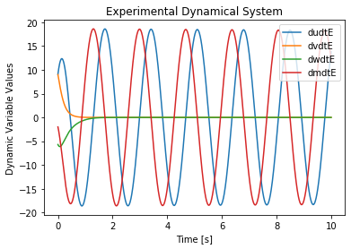

```
mean difference of dudt :
 [0.00317066]
standard deviation of error of dudt :
 0.0015226207819560504
mean difference of dvdt :
 [0.0036193]
standard deviation of error of dvdt :
 0.0004282540468571574
mean difference of dwdt :
 [2.11349479e-05]
standard deviation of error of dwdt :
 6.541813476328701e-05
mean difference of dmdt :
 [0.00322746]
standard deviation of error of dmdt :
 0.0017285705738871154


Lambda:  10.0
Mu:  10.0
Nu:  15.0
sigma:  10.0
Re:  10000.0
gamma:  0.1
delta:  1.0


Lambda experimental:  -0.0
Mu experimental:  -0.0
Nu experimental:  -0.0
sigma experimental:  -0.0
gamma experimental from dudt:  0.10052868121628847
gamma experimental from dwdt:  0.10023913308199585
delta experimental from dvdt:  0.9994304707259739
delta experimental from dwdt:  1.0007389401966815




Parameter set # 2 - trial # 2
```

```
Standard deviation of noise array:  0.2
```

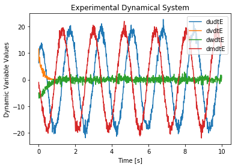

```
mean difference of dudt :
 [0.78326928]
standard deviation of error of dudt :
 0.6339796773608576
mean difference of dvdt :
 [0.07787802]
standard deviation of error of dvdt :
 0.1811511499723127
mean difference of dwdt :
 [0.60034179]
standard deviation of error of dwdt :
 0.4572910078365604
mean difference of dmdt :
 [0.80392711]
standard deviation of error of dmdt :
 0.6259327326136329


Lambda:  10.0
Mu:  10.0
Nu:  15.0
sigma:  10.0
Re:  10000.0
gamma:  0.1
delta:  1.0


Lambda experimental:  -0.0
Mu experimental:  -0.0
Nu experimental:  -0.0
sigma experimental:  -0.0
gamma experimental from dudt:  0.10054288527446151
gamma experimental from dwdt:  0.09999419588695382
delta experimental from dvdt:  0.9992780593915586
delta experimental from dwdt:  1.0004751050541674




Parameter set # 2 - trial # 3
```

```
Standard deviation of noise array:  0.4
```

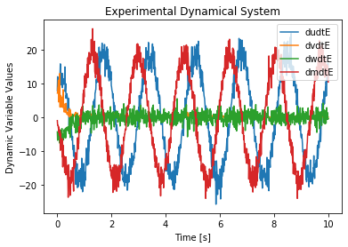

```
mean difference of dudt :
 [1.63973606]
standard deviation of error of dudt :
 1.319560524531143
mean difference of dvdt :
 [0.21538415]
standard deviation of error of dvdt :
 0.4123620077689103
mean difference of dwdt :
 [1.1871655]
standard deviation of error of dwdt :
 0.9076347178774704
mean difference of dmdt :
 [1.57601904]
standard deviation of error of dmdt :
 1.228796472435204


Lambda:  10.0
Mu:  10.0
Nu:  15.0
sigma:  10.0
Re:  10000.0
gamma:  0.1
delta:  1.0


Lambda experimental:  -0.0
Mu experimental:  -0.0
Nu experimental:  -0.0
sigma experimental:  -0.0
gamma experimental from dudt:  0.10045494456213001
gamma experimental from dwdt:  0.09997237533857939
delta experimental from dvdt:  0.9990640690321871
delta experimental from dwdt:  1.0004338697140045




Parameter set # 2 - trial # 4
```

```
Standard deviation of noise array:  0.6000000000000001
```

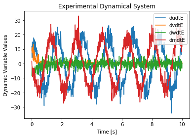

```
mean difference of dudt :
 [2.44515787]
standard deviation of error of dudt :
 2.052064964898047
mean difference of dvdt :
 [0.40021357]
standard deviation of error of dvdt :
 0.6436784300043628
mean difference of dwdt :
 [1.68776967]
standard deviation of error of dwdt :
 1.3229002087456692
mean difference of dmdt :
 [2.39556564]
standard deviation of error of dmdt :
 1.9794050299902823


Lambda:  10.0
Mu:  10.0
Nu:  15.0
sigma:  10.0
Re:  10000.0
gamma:  0.1
delta:  1.0


Lambda experimental:  -0.0
Mu experimental:  -0.0
Nu experimental:  -0.0
sigma experimental:  -0.0
gamma experimental from dudt:  0.10038031674059163
gamma experimental from dwdt:  0.0999752725555579
delta experimental from dvdt:  0.998949943601175
delta experimental from dwdt:  1.000418855772944




Parameter set # 2 - trial # 5
```

```
Standard deviation of noise array:  0.8
```

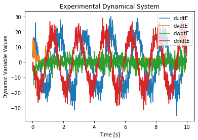

```
mean difference of dudt :
 [3.22659067]
standard deviation of error of dudt :
 2.467145281129836
mean difference of dvdt :
 [0.70511478]
standard deviation of error of dvdt :
 1.0418998641817139
mean difference of dwdt :
 [2.28135171]
standard deviation of error of dwdt :
 1.9297402400180994
mean difference of dmdt :
 [3.23186126]
standard deviation of error of dmdt :
 2.5372107387762552


Lambda:  10.0
Mu:  10.0
Nu:  15.0
sigma:  10.0
Re:  10000.0
gamma:  0.1
delta:  1.0


Lambda experimental:  -0.0
Mu experimental:  -0.0
Nu experimental:  -0.0
sigma experimental:  -0.0
gamma experimental from dudt:  0.10017462714915852
gamma experimental from dwdt:  0.09998579439664462
delta experimental from dvdt:  0.9989805281748745
delta experimental from dwdt:  1.000403900579491




Parameter set # 2 - trial # 6
```

```
Standard deviation of noise array:  1.0
```

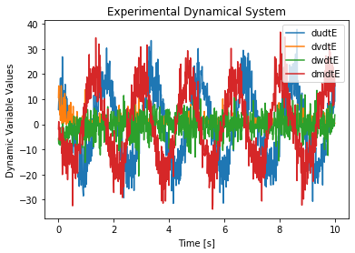

```
mean difference of dudt :
 [3.83337168]
standard deviation of error of dudt :
 2.9513324792648157
mean difference of dvdt :
 [1.16444621]
standard deviation of error of dvdt :
 1.683871198166406
mean difference of dwdt :
 [3.04308436]
standard deviation of error of dwdt :
 2.623115769025485
mean difference of dmdt :
 [3.96245189]
standard deviation of error of dmdt :
 3.278082592466873


Lambda:  10.0
Mu:  10.0
Nu:  15.0
sigma:  10.0
Re:  10000.0
gamma:  0.1
delta:  1.0


Lambda experimental:  -0.0
Mu experimental:  -0.0
Nu experimental:  -0.0
sigma experimental:  -0.0
gamma experimental from dudt:  0.10013981011586111
gamma experimental from dwdt:  0.09997926613596335
delta experimental from dvdt:  0.9991567661504533
delta experimental from dwdt:  1.000383470315435




Parameter set # 3 - trial # 1
```

```
Standard deviation of noise array:  0.0
```

[12 more figures not shown]

```
mean difference of dudt :
 [4.17820177]
standard deviation of error of dudt :
 3.1892247691146682
mean difference of dvdt :
 [9.277717]
standard deviation of error of dvdt :
 13.16829819078419
mean difference of dwdt :
 [27.62211755]
standard deviation of error of dwdt :
 23.16407703602879
mean difference of dmdt :
 [4.06600814]
standard deviation of error of dmdt :
 3.0868273925251755


Lambda:  10.0
Mu:  10.0
Nu:  15.0
sigma:  10.0
Re:  10000.0
gamma:  1.0
delta:  10.0


Lambda experimental:  -0.0
Mu experimental:  -0.0
Nu experimental:  -0.0
sigma experimental:  -0.0
gamma experimental from dudt:  1.0000634875277583
gamma experimental from dwdt:  0.9999958209564486
delta experimental from dvdt:  9.998777140540833
delta experimental from dwdt:  10.000385426901369
```

```python
        print('\n') #spacing
        print('Lambda experimental: ', lamE)
        print('Mu experimental: ', muE)
        print('Nu experimental: ', nuE)
        print('sigma experimental: ', sigmaE)
        print('gamma experimental from dudt: ', gammaEu)
        print('gamma experimental from dwdt: ', gammaEw)
        print('delta experimental from dvdt: ', deltaEv)
        print('delta experimental from dwdt: ', deltaEw)
        print('\n') #spacing
        print('\n') #spacing

        #Beeg loop end####################################################################
        beegn = beegn + 1

    beegk = beegk + 1
```

## Results and Analysis Cont.

| Parameter Set | lambda | mu | nu | sigma | delta | gamma |
| --- | --- | --- | --- | --- | --- | --- |
| W | 10 | 10 | 15 | 10 | 1 | 0.1 |

Table (1). Parameter Sets from [1] Kalur2020.pdf page (p. 4)

The code is designed to allow for the iteration of multiple parameter sets, each at increasing levels of noise according to the number of desired iterations. In this analysis four parameter sets have been chosen. The first is the parameter set found in Table (1). This set will be used as the basis for our analysis. In the first parameter set a low Reynold's Number of 1000 is used. The second set's Reynold's Number is increased to 10000. In the third set the viscous decay rates are all increased heavily. And for the fourth set the nonlinear interaction coefficients are increased instead. For each of these parameter sets noise is added to each additional iteration with the first experimental model given no noise. The standard deviation of the noise is listed before the experimental dynamical system's plot for each iteration.

## References

[1] Kalur2020.pdf

[2] Data-Driven Science and Engineering Machine Learning Dynamical Systems and Control

[3] CH07_SEC03_SINDY_Lorenz